```python
import duckdb
import json
import os
import sqlite3
import urllib
import zlib

import numpy as np
import pandas as pd

from collections import Counter
from matplotlib import pyplot as plt
from matplotlib import cm as cm
from sklearn.cluster import KMeans
from sklearn.metrics import silhouette_samples, silhouette_score
from sklearn.preprocessing import StandardScaler
from uszipcode import SearchEngine


plt.rcParams['figure.figsize'] = [10, 6]
plt.rcParams['figure.dpi'] = 100 # 200 e.g. is really fine, but slower

pd.set_option('display.max_rows', 500)
pd.set_option('display.max_columns', 500)
```

# Overview

We will be doing some clustering of zip codes based on their demographic features

The Census Bureau and other government agencies publish a lot of information about these, but it can take some effort to find and merge them all. There is a handy library called uszipcode that has compiled a number of these together. It has it's own API for interacting with the data, but it is backed by a sqlite database that it downloads. It will be simpler for us to just ingest the data from the sqlite database, rather than the API. In order to download the data, we need to first import it and specify that we want the comprehensive version of the data.

```python
## Specify your own path!
filename = 'zipcode.sqlite'
path = '/Users/yashwanth/Documents/GWU/Sem 3/Data Mining/Class 4/Assignment/zipcodes/'
dbpath = path+filename
sr = SearchEngine(db_file_path=dbpath, simple_or_comprehensive=SearchEngine.SimpleOrComprehensiveArgEnum.comprehensive)

z = sr.by_state("DC", returns=10)
## This will trigger a download of the database
```

```python
conn = sqlite3.connect(dbpath)
cursor = conn.cursor()
cursor.execute("SELECT name FROM sqlite_master WHERE type='table';")
print(cursor.fetchall())
```

```
[('simple_zipcode',), ('comprehensive_zipcode',)]
```

# Grabbing the data

For now, we are only looking at the DC area: DC, VA and MD

We are only including a few of the many 'extra' demographic fields that are in the comprehensive data. These fields are actually kind of annoying to deal with, as they are compressed and json encoded and they have a very strange format that's nested within the column. I've done the work to clean these up and convert them into separate columns.

```python
cursor.execute("SELECT * from simple_zipcode LIMIT 10")

exclude = {'common_city_list', 'area_code_list'}
regular_fields = [i[0] for i in cursor.description if i[0] not in exclude]

print(regular_fields)

encoded_fields = ["population_by_age", "population_by_race",
                  "educational_attainment_for_population_25_and_over",
                  "travel_time_to_work_in_minutes"]

fields = regular_fields + encoded_fields

field_string = ",\n    ".join(fields)
query = f"""
SELECT
    {field_string}
FROM
    comprehensive_zipcode
WHERE
    zipcode_type = 'STANDARD'
AND
    state IN ('VA', 'DC', 'MD')
"""
print(query)
```

```
['zipcode', 'zipcode_type', 'major_city', 'post_office_city', 'county', 'state', 'lat', 'lng', 'timezone', 'radius_in_miles', 'population', 'population_density', 'land_area_in_sqmi', 'water_area_in_sqmi', 'housing_units', 'occupied_housing_units', 'median_home_value', 'median_household_income', 'bou…

SELECT
    zipcode,
    zipcode_type,
    major_city,
    post_office_city,
    county,
    state,
    lat,
    lng,
    timezone,
    radius_in_miles,
    population,
    population_density,
    land_area_in_sqmi,
    water_area_in_sqmi,
    housing_units,
    occupied_housing_units,
    median_home_value,
    median_household_income,
    bounds_west,
    bounds_east,
    bounds_north,
    bounds_south,
    population_by_age,
    population_by_race,
    educational_attainment_for_population_25_and_over,
    travel_time_to_work_in_minutes
FROM
    comprehensive_zipcode
WHERE
    zipcode_type = 'STANDARD'
AND
    state IN ('VA', 'DC', 'MD')
```

```python
df = pd.read_sql_query(query, conn)
df
```

|  | zipcode | zipcode_type | major_city | post_office_city | county | state | lat | lng | timezone | radius_in_miles | population | population_density | land_area_in_sqmi | water_area_in_sqmi | housing_units | occupied_housing_units | median_home_value | median_household_income | bounds_west | bounds_east | bounds_north | bounds_south | population_by_age | population_by_race | educational_attainment_for_population_25_and_over | travel_time_to_work_in_minutes |
| --- | --- | --- | --- | --- | --- | --- | --- | --- | --- | --- | --- | --- | --- | --- | --- | --- | --- | --- | --- | --- | --- | --- | --- | --- | --- | --- |
| 0 | 23883 | STANDARD | Surry | Surry, VA | Surry County | VA | 37.13 | -76.83 | America/New_York | 7.0 | 2551.0 | 45.0 | 57.15 | 18.25 | 1227.0 | 999.0 | 174200.0 | 56324.0 | -76.840094 | -76.641581 | 37.210962 | 37.034273 | b'x\x9c\x8d\x93\xbbn\xc30\x0cE\x7f%P\xd7\x0c"%... | b'x\x9cm\x8e=\x0f\x820\x10@\xff\xca\xa5\x83\x1... | b'x\x9ce\xcf=\x0b\xc20\x10\x06\xe0\xbf\x12\xb2... | b"x\x9cM\xcc;\x0e\x840\x0c\x04\xd0\xabDn\x17Kv... |
| 1 | 23885 | STANDARD | Sutherland | Sutherland, VA | Dinwiddie County | VA | 37.19 | -77.56 | America/New_York | 5.0 | 2807.0 | 83.0 | 33.94 | 1.12 | 1138.0 | 1074.0 | 208800.0 | 75625.0 | -77.645795 | -77.505470 | 37.250782 | 37.114609 | b'x\x9c\x8d\xd3\xbbn\xc30\x0c\x05\xd0_1\xd45\x... | b"x\x9cM\x8f=\x0f\x820\x10\x86\xff\xca\xa5\x83... | b'x\x9ce\xcf=\x0b\xc20\x10\x06\xe0\xbf\x12\xb2... | b'x\x9cM\xce1\n\xc30\x0c\x05\xd0\xab\x18\xad\x... |
| 2 | 23887 | STANDARD | Valentines | Valentines, VA | Brunswick County | VA | 36.58 | -77.83 | America/New_York | 6.0 | 574.0 | 28.0 | 20.42 | 0.96 | 611.0 | 266.0 | 145100.0 | 29519.0 | -77.879894 | -77.744203 | 36.613827 | 36.544878 | b'x\x9c\x85\x93\xcbj\xc30\x10E\x7f\xc5\xa8\xdb... | b'x\x9cm\x8e\xb1\x0e\x82@\x0c\x86_\xa5\xb9\xc1... | b'x\x9ce\xcf\xb1\n\xc20\x10\x06\xe0W\tY\\:\xa8... | b"x\x9cm\xcc=\n\x800\x0c\x86\xe1\xab\x94\xac6\... |
| 3 | 23888 | STANDARD | Wakefield | Wakefield, VA | Sussex County | VA | 36.96 | -76.98 | America/New_York | 8.0 | 2275.0 | 26.0 | 87.19 | 0.51 | 1093.0 | 946.0 | 120100.0 | 40000.0 | -77.095809 | -76.845470 | 37.037233 | 36.854508 | b'x\x9c\x8d\x93\xbdN\xc30\x14F_%2k\x07_\xdb\xd... | b'x\x9cM\x8f\xb1\x0e\x820\x10\x86_\xe5\xd2\xc1... | b'x\x9ce\xcf\xb1\n\xc20\x10\x06\xe0W\tY\\:\xa8... | b'x\x9cM\xcc=\x0e\x830\x0c\x86\xe1\xabD^\x8b%\... |
| 4 | 23889 | STANDARD | Warfield | Warfield, VA | Brunswick County | VA | 36.89 | -77.74 | America/New_York | 7.0 | 581.0 | 17.0 | 33.68 | 0.09 | 276.0 | 228.0 | 115600.0 | 14875.0 | -77.844347 | -77.657867 | 36.958291 | 36.842300 | b'x\x9c\x85\x93\xcdj\xc30\x10\x06_\xc5\xa8\xd7... | b'x\x9cm\x8e\xbd\x0e\x82@\x10\x84_es\x85\x15\x... | b"x\x9cu\xcf1\x0b\xc20\x10\x05\xe0\xbfrdq\xe9P... | b'x\x9cm\xcd\xbd\n\x80 \x14\x86\xe1[\x91\xb3\x... |
| ... | ... | ... | ... | ... | ... | ... | ... | ... | ... | ... | ... | ... | ... | ... | ... | ... | ... | ... | ... | ... | ... | ... | ... | ... | ... | ... |
| 1313 | 23876 | STANDARD | Rawlings | Rawlings, VA | Brunswick County | VA | 36.94 | -77.77 | America/New_York | 7.0 | 456.0 | 13.0 | 35.93 | 0.05 | 237.0 | 194.0 | 103100.0 | 68265.0 | -77.930605 | -77.744943 | 36.995957 | 36.905559 | b'x\x9c\x8d\x93An\x830\x10E\xaf\x82\x9cm\x16x\... | b'x\x9cm\x8e\xbb\x0e\x82@\x10E\x7fe\xb2\x85\x1... | b"x\x9ce\xcf1\x0b\xc20\x10\x05\xe0\xbf\x12\xb2... | b'x\x9cM\xce=\n\x800\x0c\x80\xd1\xab\x94\xac\x... |
| 1314 | 23878 | STANDARD | Sedley | Sedley, VA | Southampton County | VA | 36.77 | -76.98 | America/New_York | 6.0 | 1118.0 | 28.0 | 39.42 | 0.29 | 502.0 | 440.0 | 157900.0 | 56667.0 | -77.097824 | -76.948124 | 36.898672 | 36.754445 | b'x\x9c\x8d\x94\xbbn\xc2@\x10E\x7f\xc5\xda\xb4... | b'x\x9cM\x8f=\x0f\x820\x10\x86\xff\xca\xa5\x83... | b'x\x9ce\xcf1\x0b\xc20\x10\x05\xe0\xbf\x12\xb2... | b"x\x9cM\xcd1\x0e\x830\x0c\x85\xe1\xabD^\xc1\x... |
| 1315 | 23879 | STANDARD | Skippers | Skippers, VA | Greensville County | VA | 36.59 | -77.60 | America/New_York | 4.0 | 679.0 | 20.0 | 33.68 | 0.12 | 344.0 | 283.0 | 92500.0 | 62188.0 | -77.671723 | -77.512040 | 36.642948 | 36.545033 | b"x\x9c\x85\x931n\xc30\x0cE\xafb\xa8k\x06Q\x94... | b'x\x9cm\x8e=\x0f\x820\x10\x86\xff\xca\xa5\x83... | b"x\x9ce\xcf\xb1\n\xc20\x10\x06\xe0W9\xb2\xb8t... | b'x\x9cM\xce9\n\x800\x10\x85\xe1\xab\x84i\xcd\... |
| 1316 | 23881 | STANDARD | Spring Grove | Spring Grove, VA | Surry County | VA | 37.16 | -76.97 | America/New_York | 15.0 | 2176.0 | 18.0 | 119.62 | 16.90 | 1096.0 | 907.0 | 188700.0 | 38295.0 | -77.170865 | -76.785476 | 37.313156 | 37.091414 | b'x\x9c\x9d\x93\xcdj\xc30\x10\x84_\xc5\xa8\xd7... | b'x\x9cM\x8fA\x0b\x82@\x10\x85\xff\xca\xb0\x87... | b'x\x9cm\xcf=\x0b\xc20\x10\x06\xe0\xbf\x12\xb2... | b"x\x9cM\xcd1\x0e\x830\x0c\x85\xe1\xabD^\xc1\x... |
| 1317 | 23882 | STANDARD | Stony Creek | Stony Creek, VA | Sussex County | VA | 36.94 | -77.40 | America/New_York | 12.0 | 2516.0 | 16.0 | 160.26 | 0.73 | 1232.0 | 1043.0 | 125000.0 | 47422.0 | -77.619478 | -77.201166 | 37.007321 | 36.824954 | b"x\x9c\x8d\x92\xcbN\xc40\x0cE\x7f\xa5\n\xdbY\... | b'x\x9cM\x8f=\x0f\x820\x10\x86\xff\xca\xa5\x83... | b'x\x9ce\xcf;\x0b\xc20\x14\x05\xe0\xbf\x12\xb2... | b'x\x9cM\xcd\xbd\n\xc30\x0c\x04\xe0W1Z\x1b\x81... |

1318 rows × 26 columns

```python
## This is a quickly put together set of cleaners for the columns that have a complex setup.

def extract(x):
    if x is None:
        return None
    else:
        extracted = json.loads(zlib.decompress(x).decode("utf-8"))
        return extracted


age_lookup = {'0': 'Under 5', '1': '5 to 9', '2': '10 to 14', '3': '15 to 19',
              '4': '20 to 24','5': '25 to 29','6': '30 to 34','7': '35 to 39','8': '40 to 44',
              '9': '45 to 49','10': '50 to 54','11': '55 to 59','12': '60 to 64','13': '65 to 69',
              '14': '70 to 74','15': '75 to 79','16': '80 to 84','17': 'above 85'}

age_lookup = {k:'population_by_age_'+'_'.join(v.split(' ')) for k,v in age_lookup.items()}

commute_mapping = {'< 10': 'commute_lt_10',
                   '10-19': 'commute_10_19',
                   '20-29': 'commute_20_29',
                   '30-39': 'commute_30_39',
                   '40-44': 'commute_40_44',
                   '45-59': 'commute_45_59',
                   '60-89': 'commute_60_89',
                   '90+': 'commute_ge_90'}

def clean_age(x):
    extracted = extract(x)
    if extracted is None:
        return None
    else:
        total = [i['values'] for i in extracted if i['key']=='Total'][0]

        data_dict = {age_lookup[str(i['x'])]:i['y'] for i in total}
        return data_dict

def clean_simple(x, prefix='population_by_race_', sep=' ', mapping=None):
    extracted = extract(x)
    if extracted is None:
        return None
    else:
        values = [i['values'] for i in extracted if i['key']=='Data'][0]
        if mapping is None:
            data_dict = {prefix+'_'.join(str(i['x']).split(sep)):i['y'] for i in values}
        else:
            data_dict = {mapping[str(i['x'])] :i['y'] for i in values}
        return data_dict

clean_race = lambda x: clean_simple(x, prefix='population_by_race_')
clean_education = lambda x: clean_simple(x, prefix='education_')
travel_time_to_work_in_minutes = lambda x: clean_simple(x, mapping=commute_mapping)

for col in encoded_fields:
    print(col)



df['population_by_age'] = df['population_by_age'].map(clean_age)
df['population_by_race'] = df['population_by_race'].map(clean_race)
df['educational_attainment_for_population_25_and_over'] = df['educational_attainment_for_population_25_and_over'].map(clean_education)
df['travel_time_to_work_in_minutes'] = df['travel_time_to_work_in_minutes'].map(travel_time_to_work_in_minutes)

ages = pd.json_normalize(df['population_by_age'])
races = pd.json_normalize(df['population_by_race'])
education = pd.json_normalize(df['educational_attainment_for_population_25_and_over'])
commute = pd.json_normalize(df['travel_time_to_work_in_minutes'])

df_merged = pd.concat([df, ages, races, education, commute], axis=1)
df = df_merged.drop(encoded_fields, axis=1)
```

```
population_by_age
population_by_race
educational_attainment_for_population_25_and_over
travel_time_to_work_in_minutes
```

```python
# OK, the data is clean, let's see what it looks like

df
```

|  | zipcode | zipcode_type | major_city | post_office_city | county | state | lat | lng | timezone | radius_in_miles | population | population_density | land_area_in_sqmi | water_area_in_sqmi | housing_units | occupied_housing_units | median_home_value | median_household_income | bounds_west | bounds_east | bounds_north | bounds_south | population_by_age_Under_5 | population_by_age_5_to_9 | population_by_age_10_to_14 | population_by_age_15_to_19 | population_by_age_20_to_24 | population_by_age_25_to_29 | population_by_age_30_to_34 | … |
| --- | --- | --- | --- | --- | --- | --- | --- | --- | --- | --- | --- | --- | --- | --- | --- | --- | --- | --- | --- | --- | --- | --- | --- | --- | --- | --- | --- | --- | --- | --- |
| 0 | 23883 | STANDARD | Surry | Surry, VA | Surry County | VA | 37.13 | -76.83 | America/New_York | 7.0 | 2551.0 | 45.0 | 57.15 | 18.25 | 1227.0 | 999.0 | 174200.0 | 56324.0 | -76.840094 | -76.641581 | 37.210962 | 37.034273 | 144.0 | 129.0 | 160.0 | 182.0 | 140.0 | 127.0 | 129.0 | … |
| 1 | 23885 | STANDARD | Sutherland | Sutherland, VA | Dinwiddie County | VA | 37.19 | -77.56 | America/New_York | 5.0 | 2807.0 | 83.0 | 33.94 | 1.12 | 1138.0 | 1074.0 | 208800.0 | 75625.0 | -77.645795 | -77.505470 | 37.250782 | 37.114609 | 139.0 | 167.0 | 169.0 | 210.0 | 145.0 | 117.0 | 139.0 | … |
| 2 | 23887 | STANDARD | Valentines | Valentines, VA | Brunswick County | VA | 36.58 | -77.83 | America/New_York | 6.0 | 574.0 | 28.0 | 20.42 | 0.96 | 611.0 | 266.0 | 145100.0 | 29519.0 | -77.879894 | -77.744203 | 36.613827 | 36.544878 | 21.0 | 20.0 | 27.0 | 21.0 | 21.0 | 13.0 | 18.0 | … |
| 3 | 23888 | STANDARD | Wakefield | Wakefield, VA | Sussex County | VA | 36.96 | -76.98 | America/New_York | 8.0 | 2275.0 | 26.0 | 87.19 | 0.51 | 1093.0 | 946.0 | 120100.0 | 40000.0 | -77.095809 | -76.845470 | 37.037233 | 36.854508 | 127.0 | 150.0 | 135.0 | 142.0 | 122.0 | 116.0 | 106.0 | … |
| 4 | 23889 | STANDARD | Warfield | Warfield, VA | Brunswick County | VA | 36.89 | -77.74 | America/New_York | 7.0 | 581.0 | 17.0 | 33.68 | 0.09 | 276.0 | 228.0 | 115600.0 | 14875.0 | -77.844347 | -77.657867 | 36.958291 | 36.842300 | 29.0 | 39.0 | 39.0 | 38.0 | 29.0 | 28.0 | 31.0 | … |
| ... | ... | ... | ... | ... | ... | ... | ... | ... | ... | ... | ... | ... | ... | ... | ... | ... | ... | ... | ... | ... | ... | ... | ... | ... | ... | ... | ... | ... | ... | … |
| 1313 | 23876 | STANDARD | Rawlings | Rawlings, VA | Brunswick County | VA | 36.94 | -77.77 | America/New_York | 7.0 | 456.0 | 13.0 | 35.93 | 0.05 | 237.0 | 194.0 | 103100.0 | 68265.0 | -77.930605 | -77.744943 | 36.995957 | 36.905559 | 19.0 | 26.0 | 17.0 | 28.0 | 24.0 | 28.0 | 22.0 | … |
| 1314 | 23878 | STANDARD | Sedley | Sedley, VA | Southampton County | VA | 36.77 | -76.98 | America/New_York | 6.0 | 1118.0 | 28.0 | 39.42 | 0.29 | 502.0 | 440.0 | 157900.0 | 56667.0 | -77.097824 | -76.948124 | 36.898672 | 36.754445 | 61.0 | 77.0 | 65.0 | 78.0 | 62.0 | 50.0 | 69.0 | … |
| 1315 | 23879 | STANDARD | Skippers | Skippers, VA | Greensville County | VA | 36.59 | -77.60 | America/New_York | 4.0 | 679.0 | 20.0 | 33.68 | 0.12 | 344.0 | 283.0 | 92500.0 | 62188.0 | -77.671723 | -77.512040 | 36.642948 | 36.545033 | 32.0 | 27.0 | 28.0 | 43.0 | 48.0 | 27.0 | 33.0 | … |
| 1316 | 23881 | STANDARD | Spring Grove | Spring Grove, VA | Surry County | VA | 37.16 | -76.97 | America/New_York | 15.0 | 2176.0 | 18.0 | 119.62 | 16.90 | 1096.0 | 907.0 | 188700.0 | 38295.0 | -77.170865 | -76.785476 | 37.313156 | 37.091414 | 110.0 | 119.0 | 129.0 | 137.0 | 130.0 | 102.0 | 96.0 | … |
| 1317 | 23882 | STANDARD | Stony Creek | Stony Creek, VA | Sussex County | VA | 36.94 | -77.40 | America/New_York | 12.0 | 2516.0 | 16.0 | 160.26 | 0.73 | 1232.0 | 1043.0 | 125000.0 | 47422.0 | -77.619478 | -77.201166 | 37.007321 | 36.824954 | 127.0 | 119.0 | 155.0 | 165.0 | 136.0 | 124.0 | 117.0 | … |

1318 rows × 62 columns

# Question 1:

Let's do a really simple set of clustering. Using population and population_density as the only features, use the KMeans from scikit-learn with k=11 to cluster the data.

KMeans documentation

Note: you may need to first handle nulls. Do not do feature scaling at this point. Use random_state=42 and n_init="auto"

Question 1a: Print the centroids out for each cluster

Question 1b: Plot the data as a scatter plot and color by the cluster label. You may find my class example useful as a guide for the color scheme from the notebook Class 4 - Clustering Simple.ipynb What do you notice about the clusters? Are both dimensions seemingly as important for the clustering?

Question 1c: Make a bar plot of the number of zip codes in each cluster.

```python
df = df.dropna(subset=['population', 'population_density'])
X = df[['population', 'population_density']]
```

```python
# 1a Print the centroids out for each cluster

kmeans = KMeans(n_clusters=11, random_state=42, n_init="auto")
kmeans.fit(X)
centroids = kmeans.cluster_centers_

print("Centroids of each cluster:")
for i, centroid in enumerate(centroids):
    print(f"Cluster {i}: {centroid}")
```

```
Centroids of each cluster:
Cluster 0: [5096.26540284  359.2985782 ]
Cluster 1: [39224.43103448  3298.36206897]
Cluster 2: [24037.24        2105.10666667]
Cluster 3: [50530.57142857  4061.14285714]
Cluster 4: [47992. 36495.]
Cluster 5: [10097.28440367   864.01834862]
Cluster 6: [1320.1730038   127.15969582]
Cluster 7: [30745.8021978   3703.21978022]
Cluster 8: [17852.4 20626.6]
Cluster 9: [62696.46666667  4249.06666667]
Cluster 10: [16233.58762887  2328.21649485]
```

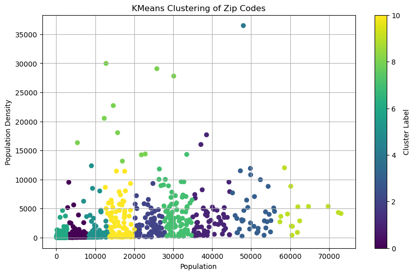

```python
# 1b: Scatter Plot Colored by Cluster Label

labels = kmeans.labels_

plt.figure(figsize=(10, 6))
plt.scatter(X['population'], X['population_density'], c=labels, cmap='viridis', marker='o')
plt.title('KMeans Clustering of Zip Codes')
plt.xlabel('Population')
plt.ylabel('Population Density')
plt.colorbar(label='Cluster Label')
plt.grid(True)
plt.show()
```

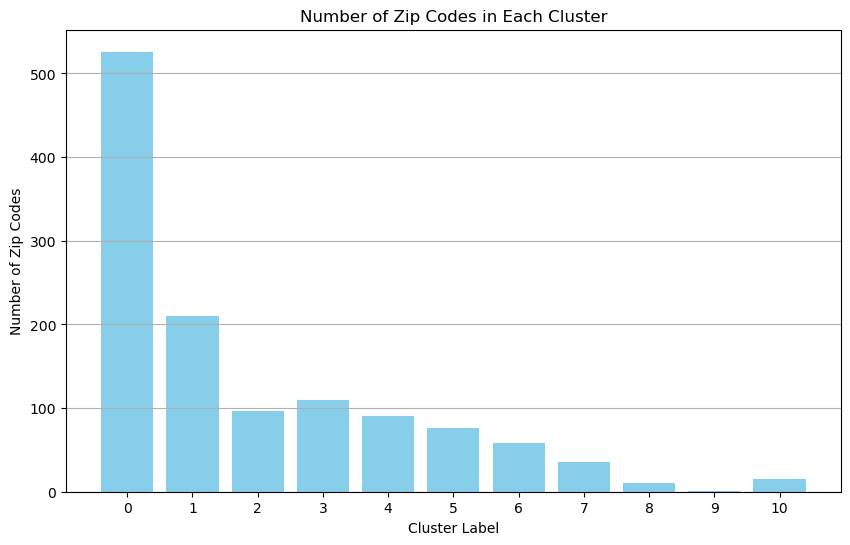

```python
# 1c: Bar Plot of the Number of Zip Codes in Each Cluster

cluster_counts = Counter(labels)

plt.figure(figsize=(10, 6))
plt.bar(range(len(cluster_counts)), cluster_counts.values(), color='skyblue')
plt.title('Number of Zip Codes in Each Cluster')
plt.xlabel('Cluster Label')
plt.ylabel('Number of Zip Codes')
plt.xticks(range(len(cluster_counts)))
plt.grid(axis='y')
plt.show()
```

# Question 2

Two of the clusters that I get (I can't guarantee we get the same results, even with random_seed=42) have much higher values of population density. Part of the problem here is that the two variables have very different typical ranges.

We can use the Standard Scaler to put all the features on the same footing.

Apply the feature scaling to your data and try the exact same clustering as before

Question 2a: Print the centroids out for each cluster

Question 2b: Plot the data as a scatter plot and color by the cluster label. How do the clusters compare to the previous plot? Is there a difference in the layout of the clusters now?

Question 2c: Make a bar plot of the number of zip codes in each cluster.

```python
df = df.dropna(subset=['population', 'population_density'])
X = df[['population', 'population_density']]
scaler = StandardScaler()
X_scaled = scaler.fit_transform(X)
```

```python
# 2a: Print the Centroids for Each Cluster

kmeans_scaled = KMeans(n_clusters=11, random_state=42, n_init="auto")
kmeans_scaled.fit(X_scaled)
centroids_scaled = kmeans_scaled.cluster_centers_
print("Centroids of each cluster after scaling:")
for i, centroid in enumerate(centroids_scaled):
    print(f"Cluster {i}: {centroid}")
```

```
Centroids of each cluster after scaling:
Cluster 0: [-0.29420969 -0.33344664]
Cluster 1: [1.98208899 1.97204279]
Cluster 2: [0.71544447 5.12194262]
Cluster 3: [1.12489559 0.18924772]
Cluster 4: [1.22244565 9.79642725]
Cluster 5: [0.59009903 2.67788858]
Cluster 6: [3.06559231 0.55945412]
Cluster 7: [-0.69434026 -0.39380264]
Cluster 8: [1.88408916 0.20381385]
Cluster 9: [ 0.36846499 -0.24509029]
Cluster 10: [0.36079907 1.06887626]
```

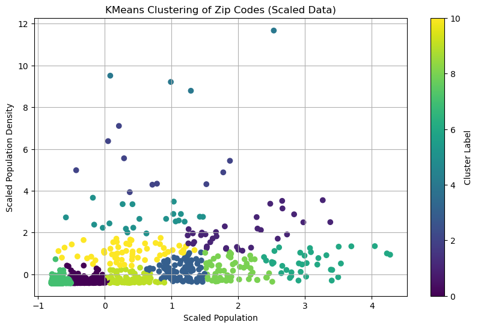

```python
# 2b: Scatter Plot Colored by Cluster Label

labels_scaled = kmeans_scaled.labels_
plt.figure(figsize=(10, 6))
plt.scatter(X_scaled[:, 0], X_scaled[:, 1], c=labels_scaled, cmap='viridis', marker='o')
plt.title('KMeans Clustering of Zip Codes (Scaled Data)')
plt.xlabel('Scaled Population')
plt.ylabel('Scaled Population Density')
plt.colorbar(label='Cluster Label')
plt.grid(True)
plt.show()
```

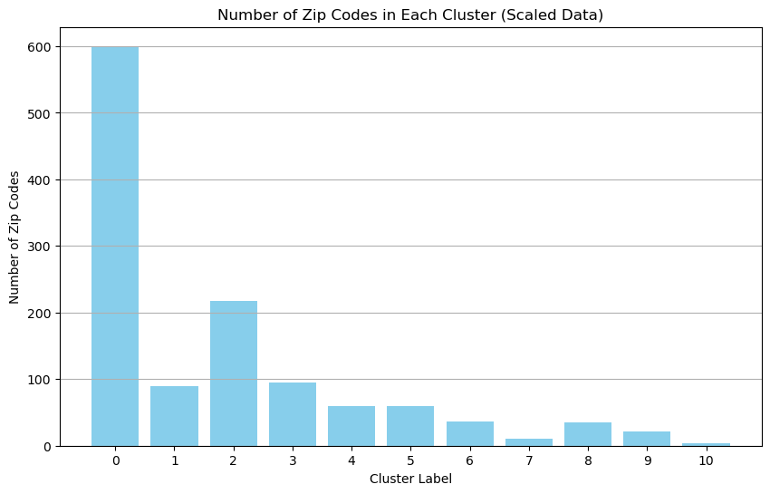

```python
# 2c: Bar Plot of the Number of Zip Codes in Each Cluster

cluster_counts_scaled = Counter(labels_scaled)
plt.figure(figsize=(10, 6))
plt.bar(range(len(cluster_counts_scaled)), cluster_counts_scaled.values(), color='skyblue')
plt.title('Number of Zip Codes in Each Cluster (Scaled Data)')
plt.xlabel('Cluster Label')
plt.ylabel('Number of Zip Codes')
plt.xticks(range(len(cluster_counts_scaled)))
plt.grid(axis='y')
plt.show()
```

# Question 3

As we discussed in class, evaluating clustering output is very challenging. We are going to try two different evaluation methods. The 1st method is going to plot silhouette scores. The second is going to use an external data source to evaluate how our clusters relate to some categories that are defined elsewhere.

I am going to call a function here for these two plots. You will need to modify variable names as appropriate

Question 3a: Compare the two silhouette scores. In my results, they are nearly the same (0.55). Looking at the plots, is there one where the clusters themselves look better? i.e., more of the clusters have at least part of their data above the average line?

```python
X = df[['population', 'population_density']].values

scaler = StandardScaler()
scaled_X2_train = scaler.fit_transform(X)
kmeans = KMeans(n_clusters=11, random_state=42, n_init='auto')
kmeans.fit(X)

kmeans2 = KMeans(n_clusters=11, random_state=42, n_init='auto')
kmeans2.fit(scaled_X2_train)
```

```
KMeans(n_clusters=11, random_state=42)
```

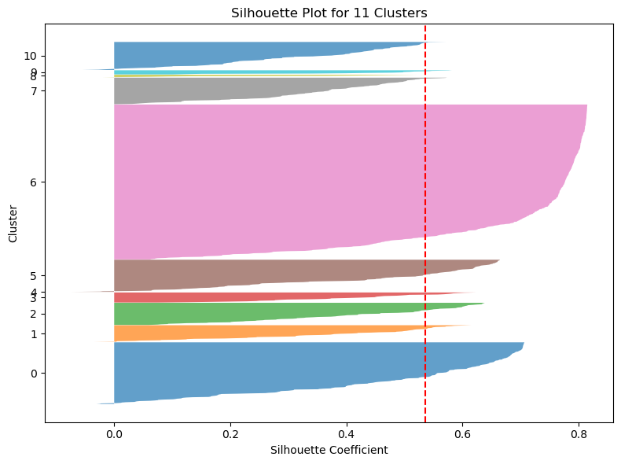

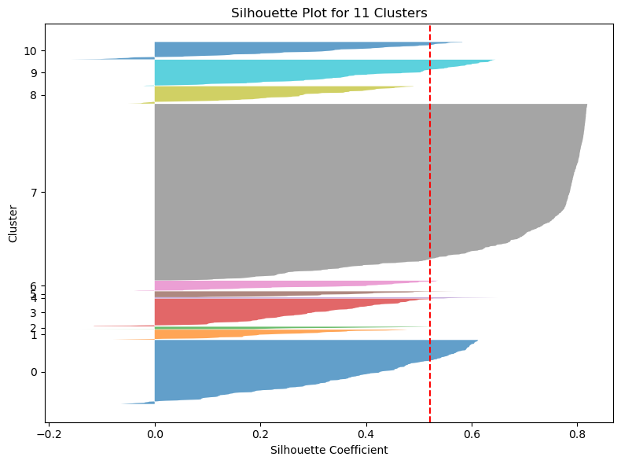

```python
def plot_silhouette_single(X, kmeans_model, plt):
    cluster_labels = kmeans_model.labels_
    n_clusters = len(np.unique(cluster_labels))

    silhouette_vals = silhouette_samples(X, cluster_labels)

    y_lower, y_upper = 0, 0
    yticks = []

    plt.figure(figsize=(8, 6))

    for i in range(n_clusters):
        ith_cluster_silhouette_vals = silhouette_vals[cluster_labels == i]
        ith_cluster_silhouette_vals.sort()

        y_upper += len(ith_cluster_silhouette_vals)
        plt.fill_betweenx(np.arange(y_lower, y_upper),
                          0, ith_cluster_silhouette_vals,
                          alpha=0.7)

        yticks.append((y_lower + y_upper) / 2)
        y_lower = y_upper

    plt.axvline(x=np.mean(silhouette_vals), color="red", linestyle="--")
    plt.yticks(yticks, range(n_clusters))
    plt.ylabel('Cluster')
    plt.xlabel('Silhouette Coefficient')
    plt.title(f'Silhouette Plot for {n_clusters} Clusters')
    plt.tight_layout()
    plt.show()

# unscaled data
plot_silhouette_single(X, kmeans, plt)

# scaled data
plot_silhouette_single(scaled_X2_train, kmeans2, plt)
```

```python
# silhouette scores
silhouette_score_unscaled = np.mean(silhouette_samples(X, kmeans.labels_))
silhouette_score_scaled = np.mean(silhouette_samples(scaled_X2_train, kmeans2.labels_))

print(f'Silhouette Score for Unscaled Data: {silhouette_score_unscaled:.3f}')
print(f'Silhouette Score for Scaled Data: {silhouette_score_scaled:.3f}')
```

```
Silhouette Score for Unscaled Data: 0.536
Silhouette Score for Scaled Data: 0.521
```

# Question 4: using outside data

The US Department of Agriculture has created a set of Rural-Urban Commuting Area Codes that categorize whether a geographic area (either by census tract or zip code) is Urban, suburban, rural, etc.

We will be using the Modified RUCA codes that add a code of 0 for "Principal City" that distinguishes between city centers and dense suburbs.

In this data, GWU's zip code of 20052 is considered a "Principal City" as are neighborhoods like Rosslyn or Bethesday, while Takoma Park is considered "Suburban core"

```python
filename = "Modified_RUCA_Zip_Codes_2010.csv"
path = '/Users/yashwanth/Documents/GWU/Sem 3/Data Mining/Class 4/Assignment/zipcodes/'
dbpath = path+filename


url = "https://raw.githubusercontent.com/jdjohn215/modified-RUCA-codes/master/Modified_RUCA_Zip_Codes_2010.csv"
if os.path.isfile(path+filename):
    print(f'file already downloaded: {filename}')
else:
    print(f'downloading file: {filename}')
    headers = urllib.request.urlretrieve(url, filename=path+filename)
    print('finished')

duckdb.sql(f'CREATE OR REPLACE TEMPORARY VIEW ruca AS (SELECT * FROM "{dbpath}")')

duckdb.sql('SELECT * FROM ruca LIMIT 10').df()
```

```
file already downloaded: Modified_RUCA_Zip_Codes_2010.csv
```

|  | zip_code | state | ruca_original | label_original | ruca_new | label_new | ruca6 | ruca5 |
| --- | --- | --- | --- | --- | --- | --- | --- | --- |
| 0 | 00001 | AK | 10 | Rural areas: primary flow to a tract outside a... | 10 | Rural areas: primary flow to a tract outside a... | Isolated rural | Rural (less than 10k |
| 1 | 00002 | AK | 10 | Rural areas: primary flow to a tract outside a... | 10 | Rural areas: primary flow to a tract outside a... | Isolated rural | Rural (less than 10k |
| 2 | 00003 | AK | 10 | Rural areas: primary flow to a tract outside a... | 10 | Rural areas: primary flow to a tract outside a... | Isolated rural | Rural (less than 10k |
| 3 | 00004 | AK | 10 | Rural areas: primary flow to a tract outside a... | 10 | Rural areas: primary flow to a tract outside a... | Isolated rural | Rural (less than 10k |
| 4 | 00005 | AK | 10 | Rural areas: primary flow to a tract outside a... | 10 | Rural areas: primary flow to a tract outside a... | Isolated rural | Rural (less than 10k |
| 5 | 00006 | AK | 10 | Rural areas: primary flow to a tract outside a... | 10 | Rural areas: primary flow to a tract outside a... | Isolated rural | Rural (less than 10k |
| 6 | 00007 | AK | 10 | Rural areas: primary flow to a tract outside a... | 10 | Rural areas: primary flow to a tract outside a... | Isolated rural | Rural (less than 10k |
| 7 | 00008 | AK | 10 | Rural areas: primary flow to a tract outside a... | 10 | Rural areas: primary flow to a tract outside a... | Isolated rural | Rural (less than 10k |
| 8 | 00009 | AK | 10 | Rural areas: primary flow to a tract outside a... | 10 | Rural areas: primary flow to a tract outside a... | Isolated rural | Rural (less than 10k |
| 9 | 00010 | AK | 10 | Rural areas: primary flow to a tract outside a... | 10 | Rural areas: primary flow to a tract outside a... | Isolated rural | Rural (less than 10k |

```python
query = '''
CREATE OR REPLACE TABLE with_ruca AS
(
    SELECT
        d.*
        , r.ruca_original
        , r.label_original
        , r.ruca_new
        , r.label_new
    FROM
        df d
    INNER JOIN
        ruca r
    ON d.zipcode = r.zip_code

)
'''
duckdb.sql(query)

df_with_ruca = duckdb.sql('SELECT * FROM with_ruca').df()
df_with_ruca[:4]
```

|  | zipcode | zipcode_type | major_city | post_office_city | county | state | lat | lng | timezone | radius_in_miles | population | population_density | land_area_in_sqmi | water_area_in_sqmi | housing_units | occupied_housing_units | median_home_value | median_household_income | bounds_west | bounds_east | bounds_north | bounds_south | population_by_age_Under_5 | population_by_age_5_to_9 | population_by_age_10_to_14 | population_by_age_15_to_19 | population_by_age_20_to_24 | population_by_age_25_to_29 | population_by_age_30_to_34 | … |
| --- | --- | --- | --- | --- | --- | --- | --- | --- | --- | --- | --- | --- | --- | --- | --- | --- | --- | --- | --- | --- | --- | --- | --- | --- | --- | --- | --- | --- | --- | --- |
| 0 | 20001 | STANDARD | Washington | Washington, DC | District of Columbia | DC | 38.91 | -77.02 | America/New_York | 2.000000 | 38551.0 | 17689.0 | 2.18 | 0.06 | 18751.0 | 16500.0 | 495300.0 | 78848.0 | -77.028292 | -77.007177 | 38.929279 | 38.890710 | 1535.0 | 1074.0 | 1048.0 | 3054.0 | 5985.0 | 6234.0 | 4334.0 | … |
| 1 | 20003 | STANDARD | Washington | Washington, DC | District of Columbia | DC | 38.88 | -76.99 | America/New_York | 2.000000 | 26454.0 | 11799.0 | 2.24 | 0.26 | 13216.0 | 11724.0 | 616000.0 | 107966.0 | -77.010791 | -76.963382 | 38.892011 | 38.867283 | 1358.0 | 788.0 | 627.0 | 820.0 | 2294.0 | 4305.0 | 3557.0 | … |
| 2 | 20004 | STANDARD | Washington | Washington, DC | District of Columbia | DC | 38.89 | -77.03 | America/New_York | 0.625000 | 1622.0 | 4659.0 | 0.35 | 0.00 | 1543.0 | 1127.0 | 470700.0 | 126765.0 | -77.039481 | -77.019899 | 38.898782 | 38.892075 | 42.0 | 5.0 | 3.0 | 12.0 | 63.0 | 256.0 | 305.0 | … |
| 3 | 20006 | STANDARD | Washington | Washington, DC | District of Columbia | DC | 38.90 | -77.04 | America/New_York | 0.738636 | 3227.0 | 9518.0 | 0.34 | 0.00 | 940.0 | 874.0 | 231700.0 | 30208.0 | -77.048850 | -77.034593 | 38.903745 | 38.892100 | 8.0 | 3.0 | 3.0 | 1484.0 | 1088.0 | 271.0 | 101.0 | … |

# Question 4 (actual questions)

Question 4a: compare the labels from our second (scaled) clustering to the ruca_new as a crosstab. Note you may need to determine how to get the labels and updated dataframe to line up, possibly redoing the clustering if it is easier.

Question 4b: What is the mutual information between the cluster labels and ruca_new ? You may want to use the normalized_mutual_info_score from sklearn. Normalized, it should not matter, but the sklearn version uses ln vs log2, so the non-normalized versions would be measured in nats instead of bits

```python
# 4a Crosstab for Labels Comparison

cluster_labels = kmeans2.labels_
df_with_ruca['cluster_labels'] = cluster_labels

df_with_ruca[['zipcode', 'cluster_labels', 'ruca_new', 'label_new']].head()
crosstab_result = pd.crosstab(df_with_ruca['cluster_labels'], df_with_ruca['ruca_new'])

print("Crosstab of Cluster Labels vs RUCA New Labels:")
print(crosstab_result)
```

```
Crosstab of Cluster Labels vs RUCA New Labels:
ruca_new        0    1    2   3   4   5   6   7   8   9   10
cluster_labels
0               29   60   67  12   3   5   4   4   5   5  24
1                1    2   11   3   1   5   0   1   1   1   9
2                0    0    6   1   0   0   0   0   0   0   3
3               11   20   32   5   1   5   3   3   3   3   9
4                0    0    0   1   0   1   0   0   0   0   2
5                1    4    4   3   0   1   0   2   1   1   4
6                3    4   20   1   0   0   0   1   0   1   6
7               76  185  182  17  11  20  11  14  20  10  53
8                7   13   21   3   1   3   2   2   3   1   4
9                8   29   26   4   2   1   3   3   3   3   8
10               4    8   18   2   1   1   0   3   4   3  16
```

```python
# 4b Calculating Mutual Information

# Import the necessary function
from sklearn.metrics import normalized_mutual_info_score

# Calculate the normalized mutual information score between 'cluster_labels' and 'ruca_new'
nmi_score = normalized_mutual_info_score(df_with_ruca['cluster_labels'], df_with_ruca['ruca_new'])

# Output the normalized mutual information score
print(f'Normalized Mutual Information Score: {nmi_score:.3f}')
```

```
Normalized Mutual Information Score: 0.031
```

# Question 5: DBSCAN

DBCAN was another of the clustering methods that we talked about in class.

It has 2 parameters:

eps: the minimum radius for clustering min_samples: what I called MinPts - the number of points for a data point to be considered 'core' It will output the number of clusters.

Question 5a: Using the example from this page DBSCAN example try using DBSCAN on this problem. How many clusters did it create? What is the Mutual Information compared to the ruca_new field?

Question 5b: do a "grid search" over eps and min_samples. Find the value that has the best normalized_mutual_info_score subject to the constraint that there should be between 7 and 15 clusters. Report out the results on the best parameters and best mutual info

Note: a grid search is a common tactic in machine learning when building models. Essentially, it is a nested loop over a range of possible parameter values. You should try a number of eps parameters and for each, you should try a number of min_samples parameters. So, if you have 5 combinations of each, you would have a 'grid' of 5x5 parameters. You do not need need to show this as a grid, but this is the general notion.

```python
# 5a: Using DBSCAN

from sklearn.cluster import DBSCAN

numeric_features = df_with_ruca.select_dtypes(include=['number']).drop(columns=['zipcode', 'ruca_new', 'cluster_labels', 'label_new'], errors='ignore')
numeric_features.fillna(numeric_features.mean(), inplace=True)

scaler = StandardScaler()
X_scaled = scaler.fit_transform(numeric_features)
dbscan = DBSCAN(eps=0.8, min_samples=3)
dbscan_labels = dbscan.fit_predict(X_scaled)
n_clusters = len(set(dbscan_labels)) - (1 if -1 in dbscan_labels else 0)
nmi_score = normalized_mutual_info_score(df_with_ruca['ruca_new'], dbscan_labels)

print(f"Number of clusters created: {n_clusters}")
print(f"Normalized Mutual Information Score: {nmi_score:.4f}")
```

```
Number of clusters created: 24
Normalized Mutual Information Score: 0.1492
```

```python
# Question 5b: Grid Search over eps and min_samples

eps_values = np.arange(0.1, 1.1, 0.2)
min_samples_values = range(2, 10)

best_nmi = -1
best_params = None

for eps in eps_values:
    for min_samples in min_samples_values:
        dbscan = DBSCAN(eps=eps, min_samples=min_samples)
        dbscan_labels = dbscan.fit_predict(X_scaled)

        n_clusters = len(set(dbscan_labels)) - (1 if -1 in dbscan_labels else 0)

        if 7 <= n_clusters <= 15:
            nmi_score = normalized_mutual_info_score(df_with_ruca['ruca_new'], dbscan_labels)
            if nmi_score > best_nmi:
                best_nmi = nmi_score
                best_params = (eps, min_samples)

print(f"Best parameters: eps = {best_params[0]}, min_samples = {best_params[1]}")
print(f"Best Normalized Mutual Information Score: {best_nmi:.4f}")
```

```
Best parameters: eps = 0.9000000000000001, min_samples = 5
Best Normalized Mutual Information Score: 0.1301
```

# Question 6:

This is an open-ended question.

We have seen that a simple clustering of the data does seem to be related to RUCA codes, but it is not a perfect predictor. We will get to how to build classification algorithms later, so our goal in this question is not to necessarily get the highest relationship to that field - a classifier would be the more appropriate factor there.

For this quesiton, I would like you to: Try out a number of different combinations of features, clusters, parameters, etc. and try to interpret the results. This is less about the number or the exact results than to get more experience with the data, handing features, etc.

What would be helpful is to do a few experiments where you articulate a hypothesis or business-case and then see how the different types of clustering affect things.

For example, if you are trying to see whether clusters can be more related to RUCA codes, you might try things like:

features, like land-area, commuting times, race, etc. may be useful in clustering data feature engineering: trying different scaling tactics. normalizing by other variables (e.g., normalize commute times by total population to get percent of people with those commute times) different numbers of clusters etc. Also, you may be interested in comparing clusters using other fields to things that you know about the area.

You may wonder how zip codes happen to cluster by other fields, like income? Or if you added income, would 'wealthy' zip codes like Potomac, MD or Great Falls, VA be more likely to be clustered together? Maybe you can find other data that is interesting for comparison? Voter preferences, for example? Please spend some effort, but do not go overboard!

Question 6: show your work and write a summary of your experience. Was it hard to interpret the results? Did you look for extra data?

```python
features = df_with_ruca[['population', 'population_density']]  # Add more features if available

scaler = StandardScaler()
X_scaled = scaler.fit_transform(features)

# Try KMeans with different numbers of clusters
for n_clusters in range(5, 16):
    kmeans = KMeans(n_clusters=n_clusters, random_state=42, n_init='auto')
    kmeans_labels = kmeans.fit_predict(X_scaled)

    # Compute NMI Score
    nmi_score = normalized_mutual_info_score(df_with_ruca['ruca_new'], kmeans_labels)
    print(f'KMeans with {n_clusters} clusters: NMI Score = {nmi_score:.4f}')

# Try DBSCAN with different eps and min_samples
eps_values = [0.3, 0.5, 0.8, 1.0]
min_samples_values = [3, 5, 7]

for eps in eps_values:
    for min_samples in min_samples_values:
        dbscan = DBSCAN(eps=eps, min_samples=min_samples)
        dbscan_labels = dbscan.fit_predict(X_scaled)

        # Count clusters
        n_clusters = len(set(dbscan_labels)) - (1 if -1 in dbscan_labels else 0)

        # Compute NMI Score
        nmi_score = normalized_mutual_info_score(df_with_ruca['ruca_new'], dbscan_labels)
        print(f'DBSCAN with eps={eps}, min_samples={min_samples}: NMI Score = {nmi_score:.4f}, Number of clusters = {n_clusters}')
```

```
KMeans with 5 clusters: NMI Score = 0.2599
KMeans with 6 clusters: NMI Score = 0.2746
KMeans with 7 clusters: NMI Score = 0.2761
KMeans with 8 clusters: NMI Score = 0.2730
KMeans with 9 clusters: NMI Score = 0.2777
KMeans with 10 clusters: NMI Score = 0.2767
KMeans with 11 clusters: NMI Score = 0.2793
KMeans with 12 clusters: NMI Score = 0.2736
KMeans with 13 clusters: NMI Score = 0.2717
KMeans with 14 clusters: NMI Score = 0.2645
KMeans with 15 clusters: NMI Score = 0.2662
DBSCAN with eps=0.3, min_samples=3: NMI Score = 0.0788, Number of clusters = 6
DBSCAN with eps=0.3, min_samples=5: NMI Score = 0.0804, Number of clusters = 2
DBSCAN with eps=0.3, min_samples=7: NMI Score = 0.0843, Number of clusters = 2
DBSCAN with eps=0.5, min_samples=3: NMI Score = 0.0453, Number of clusters = 3
DBSCAN with eps=0.5, min_samples=5: NMI Score = 0.0475, Number of clusters = 1
DBSCAN with eps=0.5, min_samples=7: NMI Score = 0.0477, Number of clusters = 1
DBSCAN with eps=0.8, min_samples=3: NMI Score = 0.0148, Number of clusters = 1
DBSCAN with eps=0.8, min_samples=5: NMI Score = 0.0203, Number of clusters = 1
DBSCAN with eps=0.8, min_samples=7: NMI Score = 0.0203, Number of clusters = 1
DBSCAN with eps=1.0, min_samples=3: NMI Score = 0.0148, Number of clusters = 3
DBSCAN with eps=1.0, min_samples=5: NMI Score = 0.0166, Number of clusters = 1
DBSCAN with eps=1.0, min_samples=7: NMI Score = 0.0185, Number of clusters = 1
```

```python
# KMeans clustering yielded better alignment with RUCA codes compared to DBSCAN, but the relationship is still weak
```